# CIBER pipeline for single-cell data

Lan-lab

6/17/2024

# Structure learning

```r
library(Seurat) # Seurat is necessary for singel-cell data
library(foreach)
library(tidyverse)
library(bnlearn) # Core package
library(Matrix) # Core package
library(space) # Core package
library(ciber)

data("HMR")
head(HMR)
```

```
##          orig.ident nCount_RNA nFeature_RNA celltype percent.mt     S.Score
## HSPC_002       HSPC  1085.3333         8778    LTHSC          0 -0.12077291
## HSPC_004       HSPC  1221.0767        11352     LMPP          0 -0.16803616
## HSPC_006       HSPC  1431.2583        11891     LMPP          0 -0.01206173
## HSPC_008       HSPC  1514.3543        10355     LMPP          0 -0.16419568
## HSPC_011       HSPC  1516.5897        10977     LMPP          0 -0.19785059
## HSPC_014       HSPC  1470.6718         9533      MPP          0 -0.16047674
## HSPC_015       HSPC   800.7971         9825     LMPP          0 -0.10753757
## HSPC_017       HSPC  1386.0569        10124    LTHSC          0 -0.17785950
## HSPC_018       HSPC  1876.0635        11314      MPP          0 -0.18039289
## HSPC_020       HSPC  1715.7519        10017    LTHSC          0 -0.15426335
##            G2M.Score Phase old.ident
## HSPC_002 -0.09083001    G1      HSPC
## HSPC_004 -0.10391938    G1      HSPC
## HSPC_006 -0.11841703    G1      HSPC
## HSPC_008 -0.12593563    G1      HSPC
## HSPC_011 -0.15114819    G1      HSPC
## HSPC_014 -0.13218429    G1      HSPC
## HSPC_015 -0.08138777    G1      HSPC
## HSPC_017 -0.12033867    G1      HSPC
## HSPC_018 -0.17387886    G1      HSPC
## HSPC_020 -0.15628029    G1      HSPC
```

```r
dim(HMR)
```

```
## [1] 40198   716
```

We use `Seurat::FindVariableFeatures` to identify the variable genes in our data set.

`gem2mem` is used to transform the single-cell data to gene expression matrix of cell types.

```r
HMR <- FindVariableFeatures(HMR, selection.method = "vst", nfeatures = nrow(HMR))
glist <- VariableFeatures(HMR)

meta <- HMR$celltype
ctypes <- names(table(HMR$celltype))
blood_celltype <- gem2mem(data.frame(HMR@assays$RNA@data), meta, "mean")
```

The following process discusses a more detailed way to learn the network.

`BNLearning` function samples the data and gives a set of possible structures with different parameters. It is necessary to set the root node manually.

```r
dag_smpl <- BNLearning(HMR[glist[1:5000]],
  frac = 0.2, N_smpl = 100, params = seq(0.05, 0.3, 0.05),
  root = "LTHSC", mode = "single_cell", ncores = 200,
  dagMethod = "hc", ugMethod = "cmi2ni"
)
net <- combineDAGsmpl(dag_smpl, Emin = 1, Emax = 7, ncores = 64)

# Let us take a glimpse of the structure now, the number indicates the occurence in previous step
net_mat <- net %>% df2mat()
net_mat
```

```
##       CMP GMP LMPP LTHSC MEP MPP
## CMP     0 290  111     0 278  16
## GMP     5   0    0     0   5   1
## LMPP   57  15    0     0   0 120
## LTHSC  30   0  118     0   4 296
## MEP     3   0    0     0   0   1
## MPP   260  12  176     0  11   0
```

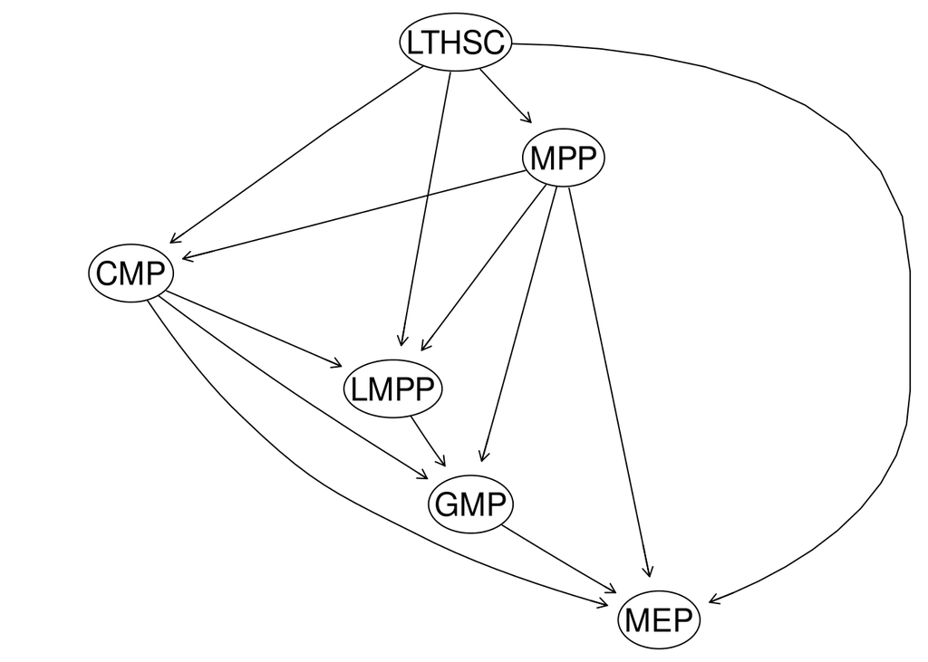

```r
net <- (net_mat * (net_mat > 2)) %>%
  mat2df() %>%
  rmCyc()
e <- df2bn(net, ctypes, plot = TRUE)
```

Our very first `e` is too complicated and unrealistic for a differentiation network. In the following step, we make use of gene variability information to prune our graph with `trimDAG`.

The parameters of `trimDAG` determines how many arcs can there be that point from or to a node. Usually, min_arc is 1 or 2, max_arc is 3 or 4. Besides, edges with too small coefficients are deleted after fitting as well. Threshold_value is normally from 0.8 to 1. Sometimes, you may need to use `trimDAG` for multiples times and on different gene sets to get a more ideal structure.

`trimDAG` automatically plots the modified structure for you. It can be turned off by manually setting `plot = FALSE`.

```r
tmp <- blood_celltype
tmp2 <- trimDAG(tmp[glist[4000:8000], ], e, min_arc = 2, max_arc = 3, threshold_value =  1)
```

[figure not shown]

[figure not shown]

```r
tmp2 <- trimDAG(tmp[glist[1:4000], ], tmp2, min_arc = 2, max_arc = 2, threshold_value =  1, plot = FALSE)
dag_struc <- tmp2
```

# Gene effects on the structure

```r
# Generate indexes for bootstrapping
index <- bootstrap_index(meta, bootstrap_times = 20, ratio = 0.3)
perturbRes <- PerturbResult(dag_struc, HMR, meta, index, n_sample = 20,
                            mode = "single_cell", ncores = 20)
effMat <- EffectMatrix(perturbRes, mode = 'mean')

ctypes <- c("CMP", "GMP", "LMPP",  "LTHSC", "MEP", "MPP")
edgeSet <- setEdges(fromSet = ctypes, toSet = ctypes) # Calculate for all edges
effectScore <- diffScore(effMat, edgeSet)
geneList <- dsRank(effectScore)
head(geneList)
```

```
## [1] "Mpo"            "Ctsg"           "Apoe"           "Plac8"
## [5] "X..not.aligned" "Car1"
```